# Olympic history: Growth and saturation

2018-xx-xx

The data used in this post can be downloaded from [figshare](https://figshare.com/articles/Olympic_history_longitudinal_data_scraped_from_www_sports-reference_com/6121274).

## Data exploration: Trends in participation

Load packages and the data into R.

```r
# load packages
library("tidyverse")
library("gridExtra")

# load data
data <- read_csv("~/Documents/GitHub/Olympic_history/data/athlete_events.csv",
                           col_types = cols(
                             ID = col_character(),
                             Name = col_character(),
                             Sex = col_factor(levels = c("M","F")),
                             Age =  col_integer(),
                             Height = col_double(),
                             Weight = col_double(),
                             Team = col_character(),
                             NOC = col_character(),
                             Games = col_character(),
                             Year = col_integer(),
                             Season = col_factor(levels = c("Summer","Winter")),
                             City = col_character(),
                             Sport = col_character(),
                             Event = col_character(),
                             Medal = col_factor(levels = c("Gold","Silver","Bronze"))
                             )
                           )
```

The following three plots chart the number of participating athletes, nations, and events in every Olympic Games in history. In all three counts, the overall trend is for the Olympics to grow in size.

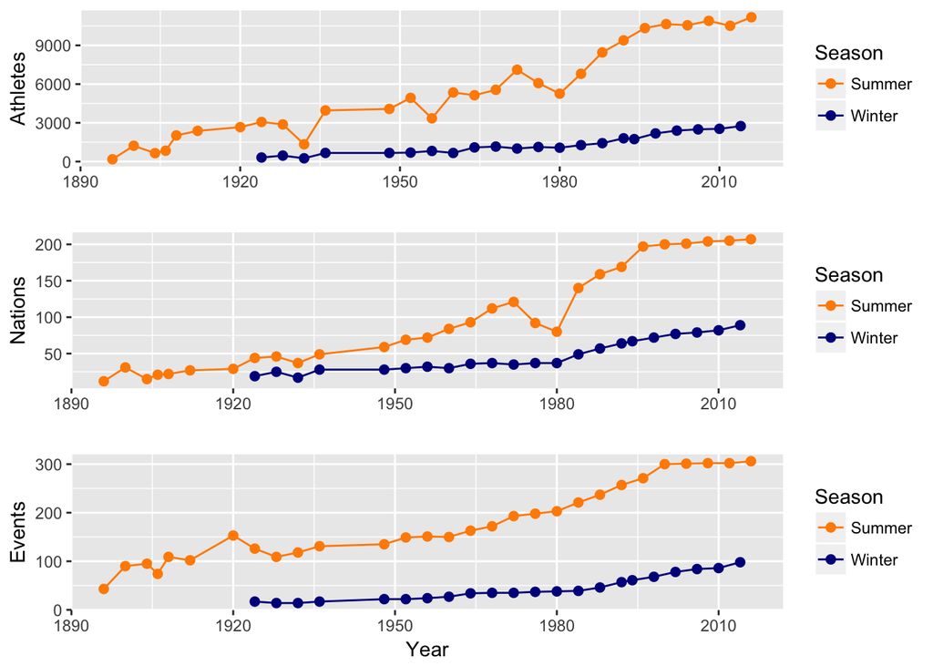

```r
# Table counting number of athletes, nations, & events
counts <- data %>% filter(Sport != "Art Competitions") %>%
  group_by(Year, Season) %>%
  summarize(
    Athletes = length(unique(ID)),
    Nations = length(unique(NOC)),
    Events = length(unique(Event))
    )

# Plot
p1 <- ggplot(counts, aes(x=Year, y=Athletes, color=Season)) +
  geom_point(size=2) +
  geom_line() +
  scale_color_manual(values=c("darkorange","darkblue")) +
  xlab("")
p2 <- ggplot(counts, aes(x=Year, y=Nations, color=Season)) +
  geom_point(size=2) +
  geom_line() +
  scale_color_manual(values=c("darkorange","darkblue")) +
  xlab("")
p3 <- ggplot(counts, aes(x=Year, y=Events, color=Season)) +
  geom_point(size=2) +
  geom_line() +
  scale_color_manual(values=c("darkorange","darkblue"))
grid.arrange(p1, p2, p3, ncol=1)
```

You can see two long periods without any Games between 1912-1920 and 1936-1948, corresponding to WWI and WWII. In addition, a few Games are highlighted where dips in attendance occur. There are:

- L.A. and Lake Placid, 1932: As these Games occured in the midst of the Great Depression and were held in remote locations, many athletes were unable to afford the trip to the Olympics, and attendence [suffered](https://history.fei.org/node/26) as a result.
- Melbourne, 1956: Attendance dipped due to several boycotts: Iraq, Egypt, and Lebanon did not participate due to the involvement of France and Britain in the [Suez Crisis](https://en.wikipedia.org/wiki/Suez_Crisis); the Netherlands, Spain, Switzerland, and Cambodia did not participate due to the Soviet Union’s beat down of the [Hungarian Revolution](https://en.wikipedia.org/wiki/Hungarian_Revolution_of_1956); and China did not participate in protest of the IOC’s [recognition](https://en.wikipedia.org/wiki/Chinese_Taipei_at_the_Olympics) of Taiwan.
- Montreal, 1976: Attendance dipped because [25 nations](https://www.nytimes.com/1976/07/18/archives/22-african-countries-boycott-opening-ceremony-of-olympic-games.html), mostly African, boycotted the Games in reponse to apartheid policies in South Africa. Attendance at the 1980 Winter Olympics in Lake Placid wasn’t affected much since African nations have a limited presence at the Winter Games.
- Moscow, 1980: Attendance dipped because [66 nations](https://www.history.com/this-day-in-history/carter-announces-olympic-boycott), including the U.S., boycotted the Games in response to the Soviet invasion of Afghanistan.

The growth trends start to level off roughly around the year 2000, at least for the Summer Games. The Olympics can only hold people’s attention for so many days of the year, and the list of events and athletes cannot grow indefinitely. The Summer Olympics may have reached a saturation point around the turn of the century, with around 200 nations, 300 events, and 10,000 athletes.

The Winter Olympics would seem to have more growing room, but ice and snow sports are simply not practical in most nations. Given trends in the climate, this doesn’t seem likely to change in the near future.